# Projekt 2, faza 1

Bartosz Sajniak

18 maja 2016

# 1. Spis treści

- 1. Spis treści
- 2. Przygotowanie danych
- 3. Bezwzględna liczba chorych
  - 3.1 Bezwzględna liczba chorych z podziałem na województwa
  - 3.2 Bezwzględna liczba chorych - mapa
- 4. Liczba zdrowych przypadających na jednego chorego
  - 4.1 Z podziałem na województwa
  - 4.2 Liczba zdrowych przypadających na jednego chorego - mapa
- 5. Liczba zdrowych na jednego chorego w powiatach
  - 5.1 Najbardziej i najmniej zdrowe powiaty
  - 5.2 Mapa
- 6. Choroba a płeć

# 2. Przygotowanie danych

Zacznijmy od przygotowania danych. Poniższy kod przyporządkowuje nazwy województw oraz powiatów, a także ludność mieszkającą oraz powierzchnię poszczególnych województw i powiatów do odpowiednich rekordów.

```r
powiaty <- getMPpowiaty(debug = 0)
gminy <- getMPgminy(debug = 0)[,c(3,4,6,10)]
gminy$teryt <- substr(gminy$teryt,1,nchar(gminy$teryt)-2)
gminy <- gminy %>% group_by(teryt,powiat.id) %>% summarise(ludnoscpowiatu = sum(as.numeric(liczba_ludnosci)), powierzchniapowiatu = sum(as.numeric(powierzchnia)))
powiaty <- merge(powiaty,gminy,by.x="id",by.y="powiat.id")[,c(2:6)]
for(i in 1:length(powiaty$nazwa))
{
  if(strsplit(powiaty$teryt[i],'')[[1]][1]==0)
  {
    powiaty$teryt[i] <- substr(powiaty$teryt[i],2,nchar(powiaty$teryt[i]))
  }
}
woj <- powiaty %>% group_by(wojewodztwo) %>% summarise(ludnoscwoj = sum(ludnoscpowiatu), powierzchniawoj = sum(powierzchniapowiatu))
powiaty <- merge(powiaty,woj,by.x="wojewodztwo",by.y="wojewodztwo")
dane <- merge(dane,powiaty,by.x="TERYT4",by.y="teryt")

ilewoj <- dane %>% group_by(wojewodztwo,ludnoscwoj) %>%summarise(chorych = sum(new))
ilewoj <- ilewoj %>% mutate(zdrowychnajednegochorego=ludnoscwoj/chorych) %>% ungroup()

ilepow <- dane %>% group_by(nazwa,ludnoscpowiatu,TERYT4) %>% summarise(chorych = sum(new))
ilepow[ilepow$TERYT4==221,"ludnoscpowiatu"] <- ilepow[ilepow$TERYT4==221,"ludnoscpowiatu"]+powiaty[powiaty$teryt==265,"ludnoscpowiatu"]
ilepow <- ilepow %>% mutate(zdrowychnajednegochorego=ludnoscpowiatu/chorych) %>% ungroup()

wojshape = readShapePoly("C:/Users/Bartek/Desktop/R/projekt2/mapa/wojew_region.shp",proj4string=CRS("+proj=longlat +ellps=clrk66")) #,IDvar="NAZ_WOJ"
```

# 3. Liczba chorych

Na sam początek sprawdźmy bezwzględne liczby chorych w poszczególnych województwach.

### 3.1 Bezwzględna liczba chorych z podziałem na województwa

Jak można zauważyć na poniższym wykresie liczba chorych w poszczególnych województwach może różnić się nawet kilkukrotnie.

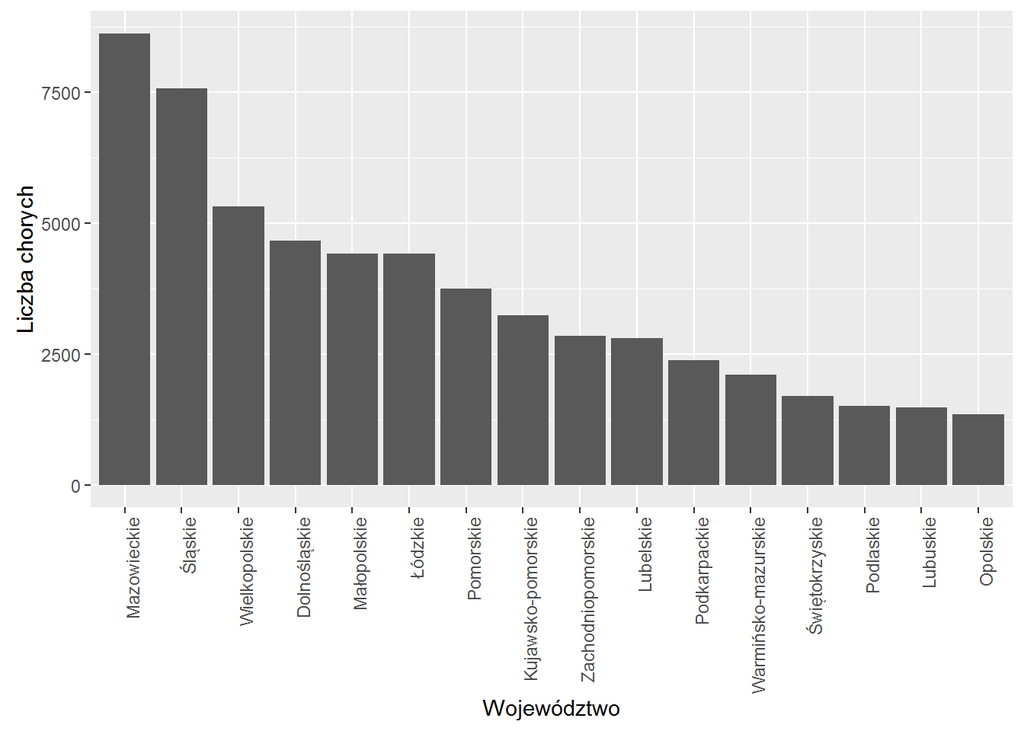

```r
ggplot(ilewoj, aes(reorder(wojewodztwo, -chorych), chorych)) + geom_bar(stat = 'identity') + xlab("Województwo") + ylab("Liczba chorych") + theme(axis.text.x = element_text(angle = 90, hjust = 1))
```

### 3.2 Bezwzględna liczba chorych - mapa

Sprawdźmy czy na mapie korzystając z tych samych danych możemy zauważyć jakieś zależności.

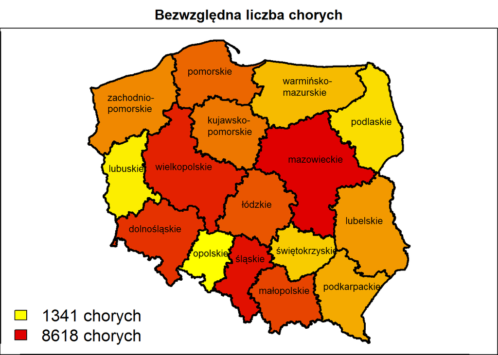

```r
kolory <- colorRampPalette(c('yellow', '#DF0000'))(length(ilewoj$chorych))[rank(ilewoj$chorych)]
ind <- c(16,11,14,10,3,6,15,5,7,9,12,8,2,4,1,13) #kolejnosc alfabetyczna wojewodztw
par(mar=c(0,0,2,0))
plot(wojshape, main="Bezwzględna liczba chorych", border="black",lwd=2.5, axes=T,col=kolory[ind])


xw = as.numeric(strsplit("14.71769 17.21543 20.19659 14.74992 16.21633 17.84389 22.32370 18.90744 20.35774 22.14644 15.37838 17.39268 18.71407 19.43922 19.98711 21.45352"," ")[[1]])
yw = as.numeric(strsplit("53.63893 54.23526 53.95697 52.37669 52.39657 53.20162 53.26125 51.68097 52.55559 51.37287 51.19397 50.72684 50.61751 50.00130 50.77654 50.08081"," ")[[1]])
nw = c("zachodnio-\npomorskie","pomorskie","warmińsko-\nmazurskie","lubuskie","wielkopolskie","kujawsko-\npomorskie","podlaskie","łódzkie","mazowieckie","lubelskie","dolnośląskie","opolskie","śląskie","małopolskie","świętokrzyskie","podkarpackie")
text(xw,yw,nw,adj=0,cex=0.8)

legend("bottomleft", "(x,y)", legend=c("1341 chorych","8618 chorych"), fill=c('yellow', '#DF0000'), bty="n",cex=1.4)
```

Na powyższej mapie nie widać specjalnych zależności, oprócz tego, że w większych(i bardziej zaludnionych) województwach jest więcej chorych. Powinniśmy, więc w jakiś sposób wyeliminować z naszych rozważań liczbę ludności zamieszkującą dany obszar.

# 4. Liczba zdrowych przypadających na jednego chorego

Aby pozbyć się przeszkadzającego nam składnika w postaci liczby ludności podzielmy liczbę ludności przez liczbę chorych. Dzięki temu uzyskamy liczbę zdrowych przypadających na jednego chorego w danym województwie.

### 4.1 Z podziałem na województwa

Sprawdźmy czy po wyeliminowaniu liczby ludności nasze dane będą wyglądały inaczej niż poprzednio. Należy pamiętać przy tym, że tym razem sprawdzamy liczbę zdrowych(na jednego chorego) - a nie jak przed chwilą liczbę chorych.

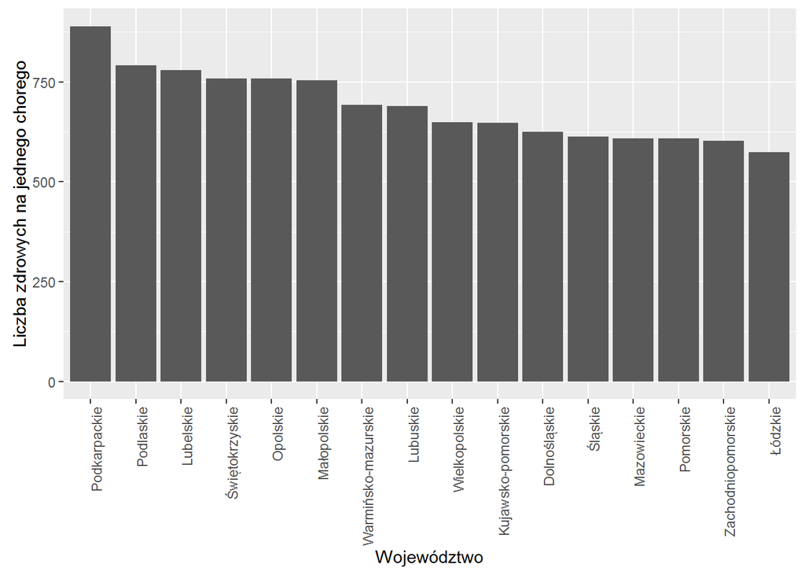

```r
ggplot(ilewoj, aes(reorder(wojewodztwo, -zdrowychnajednegochorego), zdrowychnajednegochorego)) + geom_bar(stat = 'identity') + xlab("Województwo") + ylab("Liczba zdrowych na jednego chorego") + theme(axis.text.x = element_text(angle = 90, hjust = 1))
```

Kolejność województw mocno się zmieniła(jeśli liczba ludności nie miałaby znaczenia powinna być odwrotna niż poprzednio). Widzimy teraz, więc że liczba ludności odgrywa bardzo dużą rolę na bezwzględną liczbę chorych. Sprawdźmy jak to wygląda na mapie.

### 4.2 Liczba zdrowych przypadających na jednego chorego - mapa

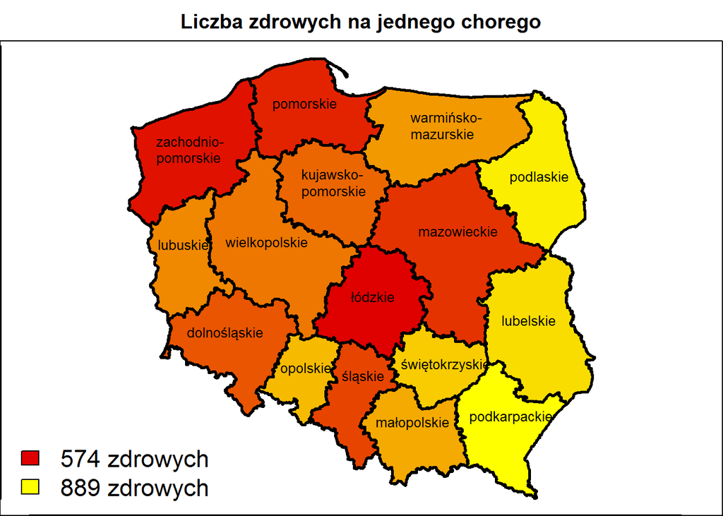

```r
kolory <- colorRampPalette(c( '#DF0000', 'yellow'))(length(ilewoj$zdrowychnajednegochorego))[rank(ilewoj$zdrowychnajednegochorego)]
par(mar=c(0,0,2,0))
plot(wojshape, main="Liczba zdrowych na jednego chorego", border="black",lwd=2.5, axes=T,col=kolory[ind])

text(xw,yw,nw,adj=0,cex=0.8)

legend("bottomleft", "(x,y)", legend=c("574 zdrowych","889 zdrowych"), fill=c('#DF0000', 'yellow'), bty="n",cex=1.4)
```

Na powyższej mapie można zauważyć, że wschodnia Polska jest najbardziej zdrowa, a najwięcej zdrowych na jednego chorego przypada w województwie podkarpackim. Patrząc na mape(a w szczególności województwo mazowieckie) można przypuszczać, że to obecność większych miast zwiększa prawdopodobieństwo zachorowania na raka. Sprawdźmy, więc tą tezę.

# 5. Liczba zdrowych na jednego chorego w powiatach

### 5.1 Najbardziej i najmniej zdrowe powiaty

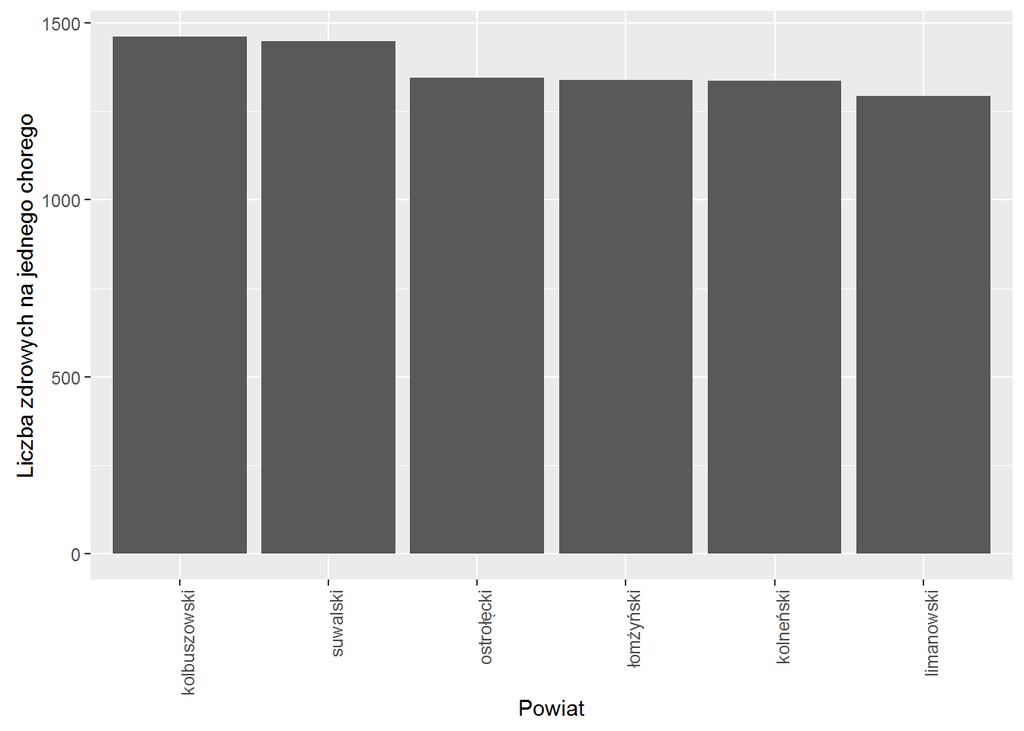

```r
ilepow <- ilepow %>% arrange(zdrowychnajednegochorego)

ggplot(tail(ilepow), aes(reorder(nazwa, -zdrowychnajednegochorego), zdrowychnajednegochorego)) + geom_bar(stat = 'identity') + xlab("Powiat") + ylab("Liczba zdrowych na jednego chorego") + theme(axis.text.x = element_text(angle = 90, hjust = 1))
```

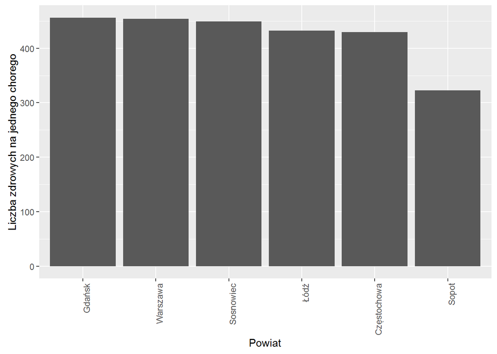

```r
ggplot(head(ilepow), aes(reorder(nazwa, -zdrowychnajednegochorego), zdrowychnajednegochorego)) + geom_bar(stat = 'identity') + xlab("Powiat") + ylab("Liczba zdrowych na jednego chorego") + theme(axis.text.x = element_text(angle = 90, hjust = 1))
```

Jak widać hipoteza z poprzedniego punktu się potwierdza, najmniej zdrowych przypadających na jednego chorego jest w większych miastach, natomiast najwięcej zdrowych - zgodnie z poprzednią intuicją jest w powiatach znajdujących się na wschodzie Polski. Zobaczmy jak to wygląda na mapie.

### 5.2 Mapa

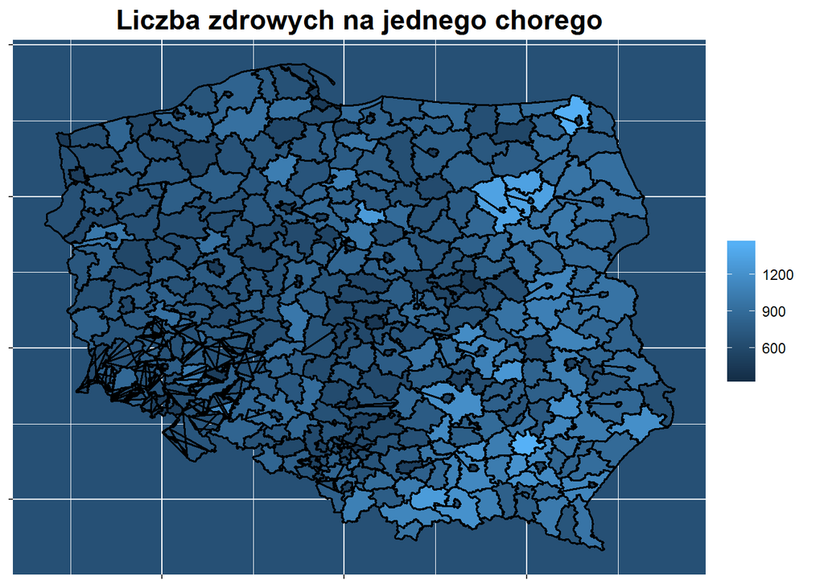

```r
poww = readShapePoly("C:/Users/Bartek/Desktop/R/projekt2/teryt-master/raw_data/powiaty.shp",proj4string=CRS("+proj=longlat +ellps=clrk66"))
poww <- fortify(poww, region="jpt_kod_je")

ilepow2 <- ilepow

ilepow2$TERYT4 <- as.character(ilepow2$TERYT4)

for(i in 1:length(ilepow2$nazwa))
{
  if(nchar(as.character(ilepow2[i,"TERYT4"]))==3)
  {
    ilepow2[i,"TERYT4"] <- paste("0", ilepow2[i,3], sep = "")
  }
}
plotData <- merge(poww, ilepow2,by.x="id",by.y="TERYT4")
ggplot() + geom_polygon(data = plotData, aes(x = long, y = lat, group = id, fill=zdrowychnajednegochorego), color='black', lwd=0.6) + theme(panel.background = element_rect(fill = "#265075"),axis.line=element_blank(),axis.text.x=element_blank(),axis.text.y=element_blank(), axis.title.x=element_blank(), axis.title.y=element_blank(),plot.title = element_text(size=17, face="bold"),legend.title=element_blank()) + ggtitle("Liczba zdrowych na jednego chorego")
```

Zgodnie z tym czego się spodziewaliśmy - wschodnie oraz południowo-wschodnie powiaty mają dużo jaśniejszy kolor co oznacza większą liczbę zdrowych osób przypadających na jednego chorego. Załamanie linii ludzi zdrowszych następuję w Warszawie i powiatach sąsiadujących. Ponadto widać wyraźnie, że w powierzchniowo mniejszych powiatach, tzn. takich gdzie jedno miasto stanowi powiat jest dużo większy odsetek chorych. Uwage przyciągają też trzy sąsiadujące ze sobą powiaty o stosunkowo dużej liczbie zdrowych: ostrołęcki, łomżyński oraz kolneński.

# 6. Choroba a płeć

W Polsce jest niecałe 52% kobiet, natomiast wśród posiadanych danych o osobach chorych wiemy, że wśród nich jest ponad 97% kobiet. Wynika z tego, że odsetek chorych mężczyzn jest marginalny i nie ma większego sensu analizować osobno obu płci. Natomiast pokazuje to, że liczby zdrowych kobiet na jedną chorą w poszczególnych powiatach są jeszcze dużo mniejsze niż w powyższych przykładach.